# Lab 6

## Lab 6 - Danielle Goedhart

**Setup**

```r
library(readr)
library(dplyr)
mt_samples <- read_csv("https://raw.githubusercontent.com/USCbiostats/data-science-data/master/00_mtsamples/mtsamples.csv")
mt_samples <- mt_samples |>
  select(description, medical_specialty, transcription)

head(mt_samples)
```

```
# A tibble: 6 × 3
  description                                    medical_specialty transcription
  <chr>                                          <chr>             <chr>
1 A 23-year-old white female presents with comp… Allergy / Immuno… "SUBJECTIVE:…
2 Consult for laparoscopic gastric bypass.       Bariatrics        "PAST MEDICA…
3 Consult for laparoscopic gastric bypass.       Bariatrics        "HISTORY OF …
4 2-D M-Mode. Doppler.                           Cardiovascular /… "2-D M-MODE:…
5 2-D Echocardiogram                             Cardiovascular /… "1.  The lef…
6 Morbid obesity.  Laparoscopic antecolic anteg… Bariatrics        "PREOPERATIV…
```

**Question 1**

```r
mt_samples |>
  count(medical_specialty, sort = TRUE)
```

```
# A tibble: 40 × 2
   medical_specialty                 n
   <chr>                         <int>
 1 Surgery                        1103
 2 Consult - History and Phy.      516
 3 Cardiovascular / Pulmonary      372
 4 Orthopedic                      355
 5 Radiology                       273
 6 General Medicine                259
 7 Gastroenterology                230
 8 Neurology                       223
 9 SOAP / Chart / Progress Notes   166
10 Obstetrics / Gynecology         160
# ℹ 30 more rows
```

The dataset contains 40 different specialties, which are not evenly distributed. For example, Surgery has 1103 counts while Hospice - Palliative Care only has 6 counts. They might be overlapping. Surgery is a very broad category, and could potentially be overlapping and related with categories like Orthopedic or Neurology.

**Question 2**

```r
library(tidytext)
library(ggplot2)

word_counts <- mt_samples |>
  unnest_tokens(word, transcription) |>
  count(word, sort = TRUE)

word_counts
```

```
# A tibble: 23,647 × 2
   word         n
   <chr>    <int>
 1 the     149888
 2 and      82779
 3 was      71765
 4 of       59205
 5 to       50632
 6 a        42810
 7 with     35815
 8 in       32807
 9 is       26378
10 patient  22065
# ℹ 23,637 more rows
```

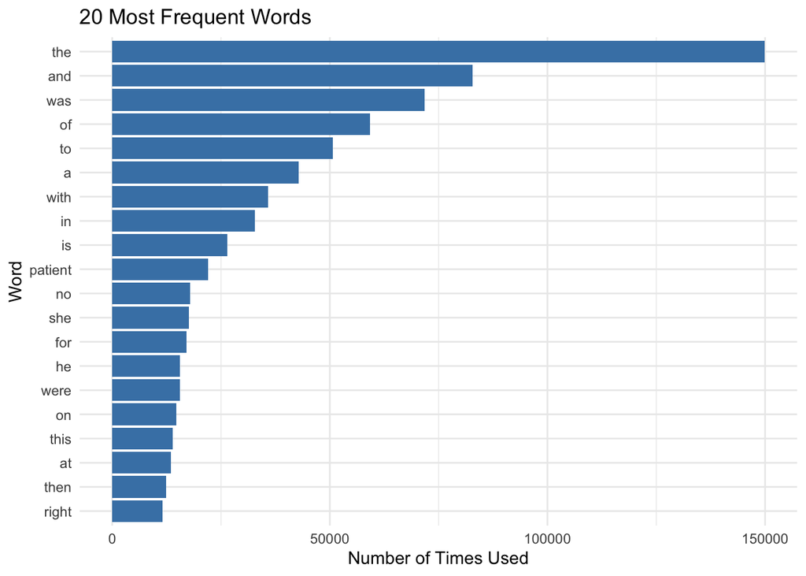

```r
word_counts |>
  slice_max(order_by = n, n = 20) |>
  mutate(word = reorder(word, n)) |>
  ggplot(aes(x = n, y = word)) +
  geom_col(fill = "steelblue") +
  labs(
    title = "20 Most Frequent Words",
    x = "Number of Times Used",
    y = "Word"
  ) +
  theme_minimal()
```

When looking at the table, we can see that the word ‘the’ occurs 149888 times, which is the most frequent. The second most frequently used is ‘and’, which is used 82779 times. The table has 23647 rows, meaning that there are 23647 different words. When looking at the table, we can see how many times the 20 most frequent words are used. When looking at the table, we can see that ‘the’ is by far the most used, and that ‘and’, which is second most used, has way less counts that the first word. The following words have only a small difference between the number of times they are used: ‘no,’ ‘she,’ ‘for,’ ‘he,’ ‘were,’ ‘on,’ ‘this,’ ‘at,’ ‘then,’ and ‘right.’

**Question 3**

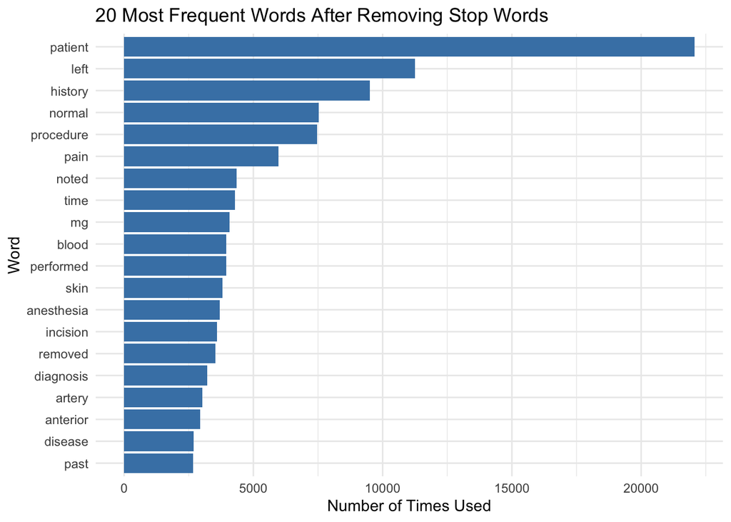

```r
word_counts_clean <- mt_samples |>
  unnest_tokens(word, transcription) |>
  anti_join(stop_words, by = "word") |>
  filter(!grepl("^[0-9]+$", word)) |>
  count(word, sort = TRUE)

word_counts_clean |>
  slice_max(order_by = n, n = 20, with_ties = FALSE) |>
  mutate(word = reorder(word, n)) |>
  ggplot(aes(x = n, y = word)) +
  geom_col(fill = "steelblue") +
  labs(
    title = "20 Most Frequent Words After Removing Stop Words",
    x = "Number of Times Used",
    y = "Word"
  ) +
  theme_minimal()
```

After removing stop words and numbers, ‘patient’ is the most used word by far. This gives us a way better idea of what the text is about. Almost all words that are left, are related to the medical fields. Words like ‘patient,’ ‘procedure,’ ‘anesthesia,’ and ‘incision’ are all related to medical procedures.

**Question 4**

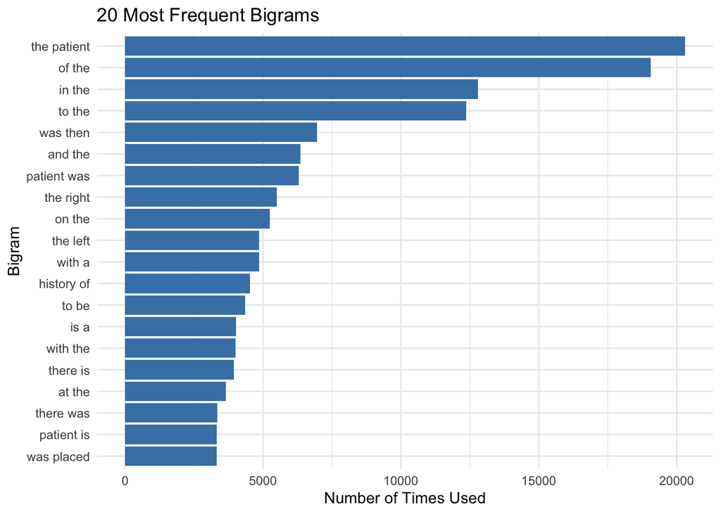

```r
# Bigrams
bigram_counts <- mt_samples |>
  unnest_tokens(
    bigram,
    transcription,
    token = "ngrams",
    n = 2
  ) |>
  filter(!is.na(bigram)) |>
  count(bigram, sort = TRUE)

bigram_counts |>
  slice_max(order_by = n, n = 20, with_ties = FALSE) |>
  mutate(bigram = reorder(bigram, n)) |>
  ggplot(aes(x = n, y = bigram)) +
  geom_col(fill = "steelblue") +
  labs(
    title = "20 Most Frequent Bigrams",
    x = "Number of Times Used",
    y = "Bigram"
  ) +
  theme_minimal()
```

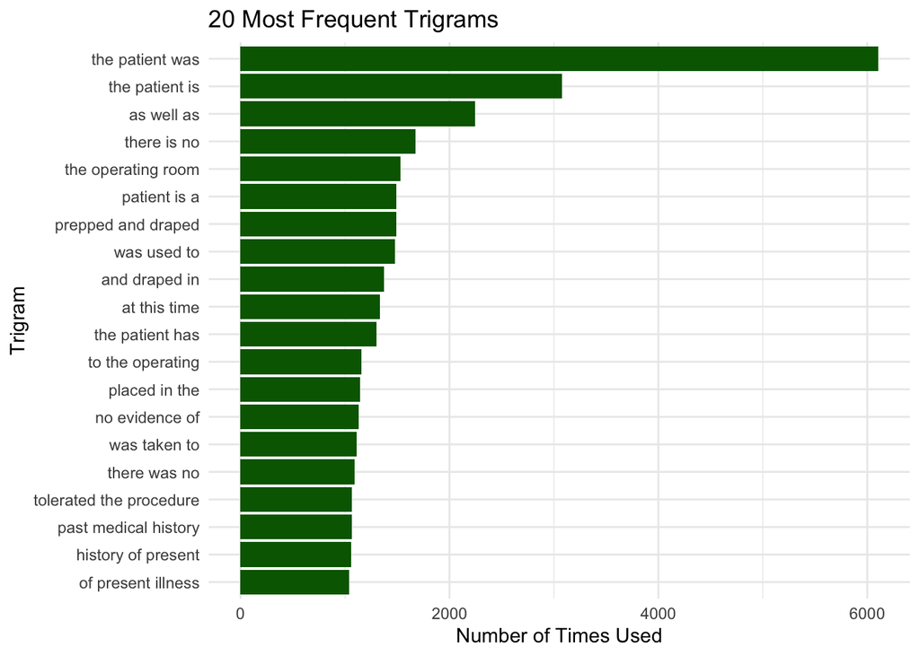

```r
# Trigrams
trigram_counts <- mt_samples |>
  unnest_tokens(
    trigram,
    transcription,
    token = "ngrams",
    n = 3
  ) |>
  filter(!is.na(trigram)) |>
  count(trigram, sort = TRUE)

trigram_counts |>
  slice_max(order_by = n, n = 20, with_ties = FALSE) |>
  mutate(trigram = reorder(trigram, n)) |>
  ggplot(aes(x = n, y = trigram)) +
  geom_col(fill = "darkgreen") +
  labs(
    title = "20 Most Frequent Trigrams",
    x = "Number of Times Used",
    y = "Trigram"
  ) +
  theme_minimal()
```

When looking at the bigrams, ‘the patient’ is the most common bigram, closely followed by ‘of the’. A lot of the bigrams contain stop words, so it does not give us a great insight. The most common used trigram is ‘the patient was’, which is by far most common. After that, starting at ‘there is no’, the number of times the trigrams are used is pretty close to each other.

**Question 5**

```r
bigrams_separated <- bigram_counts |>
  tidyr::separate(
    bigram,
    into = c("word1", "word2"),
    sep = " "
  )

before_patient <- bigrams_separated |>
  filter(word2 == "patient") |>
  arrange(desc(n))

before_patient |>
  slice_head(n = 10)
```

```
# A tibble: 10 × 3
   word1     word2       n
   <chr>     <chr>   <int>
 1 the       patient 20307
 2 this      patient   470
 3 history   patient   101
 4 a         patient    67
 5 and       patient    47
 6 procedure patient    32
 7 female    patient    26
 8 with      patient    25
 9 use       patient    24
10 old       patient    23
```

```r
after_patient <- bigrams_separated |>
  filter(word1 == "patient") |>
  arrange(desc(n))

after_patient |>
  slice_head(n = 10)
```

```
# A tibble: 10 × 3
   word1   word2         n
   <chr>   <chr>     <int>
 1 patient was        6293
 2 patient is         3332
 3 patient has        1417
 4 patient tolerated   994
 5 patient had         888
 6 patient will        616
 7 patient denies      552
 8 patient and         377
 9 patient states      363
10 patient does        334
```

The word chosen was ‘patient.’ The word that occurs most frequently before the word ‘patient’ is ‘the’, with a count of 20307, which is far ahead of second most used which is ‘this’, only used 470 times. The word most frequently used after ‘patient’ is ‘was’ with a count of 6293 times. The second most used word after was ‘is’ with a count of 3332.

**Question 6**

```r
specialty_words <- mt_samples |>
  unnest_tokens(word, transcription) |>
  anti_join(stop_words, by = "word") |>
  count(medical_specialty, word) |>
  group_by(medical_specialty) |>
  slice_max(order_by = n, n = 5, with_ties = FALSE) |>
  arrange(medical_specialty, desc(n))

print(specialty_words, n = Inf)
```

```
# A tibble: 200 × 3
# Groups:   medical_specialty [40]
    medical_specialty             word             n
    <chr>                         <chr>        <int>
  1 Allergy / Immunology          history         38
  2 Allergy / Immunology          noted           23
  3 Allergy / Immunology          patient         22
  4 Allergy / Immunology          allergies       21
  5 Allergy / Immunology          nasal           13
  6 Autopsy                       left            83
  7 Autopsy                       1               66
  8 Autopsy                       inch            59
  9 Autopsy                       neck            55
 10 Autopsy                       anterior        47
 11 Bariatrics                    patient         62
```

[output cut: 189 more lines]

The table displays the 5 most used word per specialty, excluding stop words.

**Question 7**

```r
pain_by_specialty <- mt_samples |>
  unnest_tokens(word, transcription) |>
  group_by(medical_specialty) |>
  summarize(
    total_words = n(),
    pain_count = sum(word == "pain"),
    pain_per_1000 = pain_count / total_words * 1000
  ) |>
  arrange(desc(pain_per_1000))

pain_by_specialty
```

```
# A tibble: 40 × 4
   medical_specialty             total_words pain_count pain_per_1000
   <chr>                               <int>      <int>         <dbl>
 1 Chiropractic                        13446        187         13.9
 2 Physical Medicine - Rehab            9715         95          9.78
 3 IME-QME-Work Comp etc.              17889        152          8.50
 4 Letters                             11895         80          6.73
 5 Emergency Room Reports              43598        273          6.26
 6 Hospice - Palliative Care            4171         19          4.56
 7 Rheumatology                         5059         23          4.55
 8 General Medicine                   126790        567          4.47
 9 Discharge Summary                   45362        180          3.97
10 SOAP / Chart / Progress Notes       62253        239          3.84
# ℹ 30 more rows
```

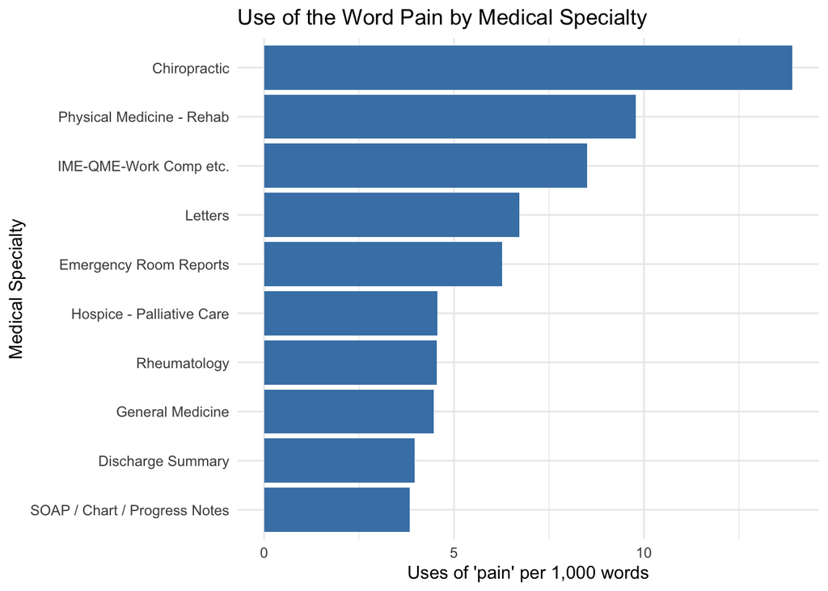

```r
pain_by_specialty |>
  slice_max(
    order_by = pain_per_1000,
    n = 10,
    with_ties = FALSE
  ) |>
  mutate(
    medical_specialty = reorder(
      medical_specialty,
      pain_per_1000
    )
  ) |>
  ggplot(aes(x = pain_per_1000, y = medical_specialty)) +
  geom_col(fill = "steelblue") +
  labs(
    title = "Use of the Word Pain by Medical Specialty",
    x = "Uses of 'pain' per 1,000 words",
    y = "Medical Specialty"
  ) +
  theme_minimal()
```

I looked at how frequently the word ‘pain’ was used in every specialty. When looking at the graph, ‘pain’ is most often used in the chiropractic. I calculated the amount of times the word was used per 1000 words, since the different specialties contain a different amount of text, so I normalized it to a 1000 words. It is secondly most used in physical medicine - rehab.